# PROYECCIÓN DE LOS ESTUDIANTES DE LA UNIVERSIDAD DE INGENIERIA Y TECNOLOGIA PARA REALIZAR ESTUDIOS DE POSGRADO EN UNIVERSIDADES DENTRO Y FUERA DEL PERÚ DURANTE EL AÑO 2023.

Hay varios factores que podrían explicar esta tendencia. Entre ellos tenemos: el acceso a becas, préstamos estudiantiles y ayudas financieras , puede nivelar las diferencias económicas y permitir que estudiantes con ingresos más bajos continúen con sus estudios de posgrado.

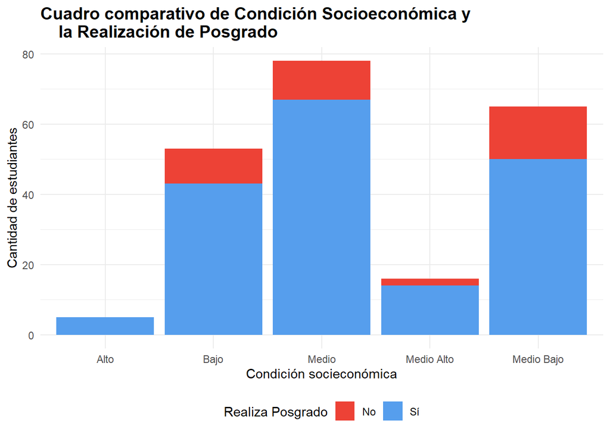

```r
ZZ %>%
 filter(!is.na(Condi_socio)) %>%
 ggplot() +
  aes(x = Condi_socio, fill = Realiza_Posgrado) +
  geom_bar() +
  scale_fill_manual(
    values = c(No = "#ED4236",
    Sí = "#569EED")
  ) +
  labs(
    x = "Condición socieconómica",
    y = "Cantidad de estudiantes",
    title = "Cuadro comparativo de Condición Socioeconómica y
    la Realización de Posgrado",
    fill = "Realiza Posgrado"
  ) +
  theme_minimal() +
  theme(
    legend.position = "bottom",
    plot.title = element_text(size = 14L,
    face = "bold")
  )
```

La gráfica de barras muestra que la mayoría de los encuestados que planean realizar estudios de posgrado tienen un nivel socioeconómico medio. Sin embargo, se observa que hay una mínima diferencia entre los niveles socioeconómicos Medio bajo y Bajo en términos de intención de realizar estudios de posgrado.

Este hallazgo sugiere que el nivel socioeconómico no es necesariamente un factor determinante en la decisión de continuar con estudios de posgrado. Aunque es común asumir que los estudiantes de niveles socioeconómicos más altos tienen más acceso a recursos y oportunidades educativas, esta gráfica muestra que la intención de realizar estudios de posgrado no está fuertemente asociada con el nivel socioeconómico.

Existen varios factores que podrían explicar esta mínima diferencia entre los niveles socioeconómicos medio bajo y bajo en términos de intención de realizar estudios de posgrado. Además, los programas de becas y ayudas financieras pueden ser una opción para estudiantes de niveles socioeconómicos medio bajo y bajo, lo que podría eliminar o reducir la barrera económica para continuar con estudios de posgrado.

**3 OBJETIVO** Examinar las preferencias de los estudiantes de la Universidad de Ingeniería y Tecnología por universidades nacionales y extranjeras según carreras que están estudiando para continuar sus estudios de posgrado durante el año 2023.

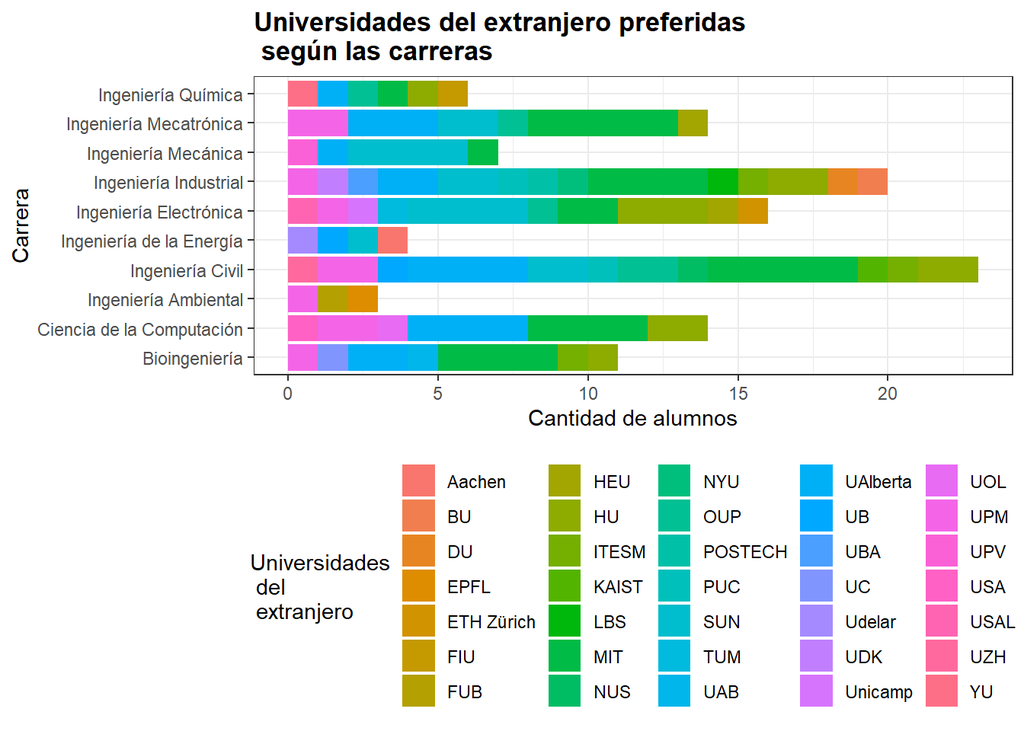

```r
library(dplyr)
library(ggplot2)

ZZ %>%
 filter(!(Carrera %in% c("Ingenieria Electronica", "Ingenieria Mecatronica"))) %>%
 filter(!is.na(U_del_Extran)) %>%
 ggplot() +
 aes(x = Carrera, fill = U_del_Extran) +
 geom_bar() +
 scale_fill_hue(direction = 1) +
 labs(y = "Cantidad de alumnos",
 title = "Universidades del extranjero preferidas
 según las carreras", fill = "Universidades
 del
 extranjero") +
 coord_flip() +
 theme_bw() +
 theme(legend.position = "bottom", plot.title = element_text(face = "bold"))
```

**COPLEMENTANDO CON UN MAPA DE CALOR**

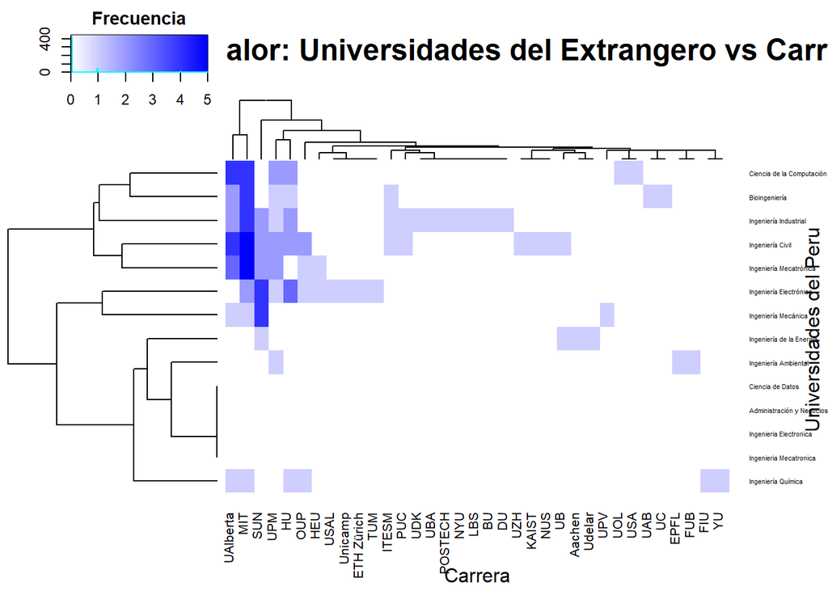

```r
# Cargar el paquete "gplots"
library(gplots)
# Crear una tabla de contingencia
tabla_contingencia <- table(ZZ$Carrera, ZZ$U_del_Extran)

# Generar el mapa de calor con heatmap.2()
heatmap.2(as.matrix(tabla_contingencia),
          trace = "none",
          col = colorRampPalette(c("white", "blue"))(100),
          xlab = "Carrera",
          ylab = "Universidades del Peru ",
          main = "Mapa de calor: Universidades del Extrangero vs Carrera",
          key = TRUE,
          key.title = "Frecuencia",
          key.xlab = "",
          key.ylab = "",
          cexCol = 0.8,  # Tamaño de las etiquetas de las columnas
          cexRow = 0.4  # Tamaño de las etiquetas de las filas
)
```